# Supervised Learning Capstone

A Nation of Debtors

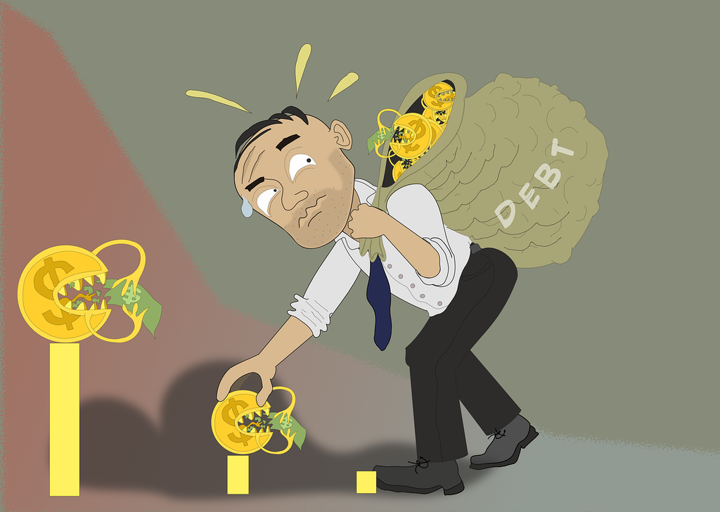

Farooq Hassan

November 22, 2019

# Purpose

Goal

Improve the gross margin of LendingClub through the identification of problematic loans at the time of issuance for further analysis and/or allocation to securitization facilities.

Objective

Develop a supervised learning model that can effectively predict whether a loan will be fully paid off or charged off at the time of loan approval.

# Introduction

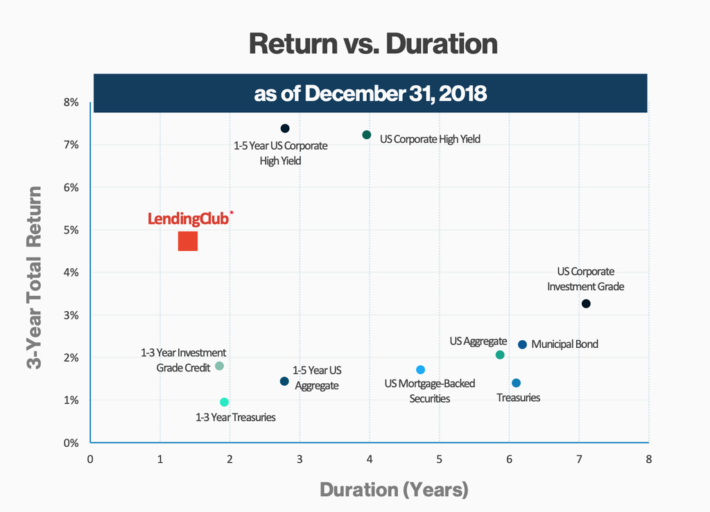

Source : LendingClub, Brismo, Morningstar, and Barclays Live, as of 12/31/2018

LendingClub (NYSE: LC) is a peer-to-peer lending platform that pairs insititutional and individual investors with borrowers.

LendingClub's top 10 institutional investors hold 54% of the loans outstanding.

# Overview

[figure not shown]

The business model is dependent upon credit creation in the US as well as an adequate Net Interest Margin (NIM).

LendingClub generates the majority of their revenues from loan origination fees and loan servicing fees. Borrowers pay an origination fee of 0% to 6% of the total loan amount as issuance. The company charges a 1% servicing fee on the monthly loan payment. If a borrower defaults on their loan, LendingClub does not provide any reimbursement. LendingClub holds approximately 40% of the loans orignated on the platform as investments. Therefore improving defaults rates is beneficial to the company as well investors.

# Data

The data is compiled of 15 csv files downloaded from LendingClub's website by creating an account. The data can be accessed at the following URL: https://www.lendingclub.com/info/download-data.action

The data is from Q1 2016 to Q3 2019 and is comprised of 1.7MM rows with 150 columns.

The underlying data set used to train and test the models was a list of customers who had applied and been approved for a loan from LendingClub between January 2016 and September 2019.

A data dictionary library was provided in excel format that provided a brief description of each variable.

# Exploratory Data Analysis

The data was reviewed by first examining the Dataset Dicitionary Library provided by LendingClub and later reading the 2019 10-K (Annual) and most recent 10-Q (Quarterly) filings.

Description of Features:

There were a total of 139 continuous variables and 11 categorical variables.

Data Cleaning:

In order to make an objective comparions of the loans, the data for individual loans were reviewed while joint loans and their attributable features were removed.

A subjective best attempt was conducted to remove all columns that contained values after the loan was approved.

Features that were not necessary such as specific ids, post loan information, redundant and investor only were also dropped.

This reduced the potential features from 149 to 61.

# EDA Continued

Data Cleaning and Transformating:

Cleaning up the data and transforming them to get them ready for analysis.

- Changed "Fully Paid" to 0 making it numeric
- Changed "Charged Off" to 1 making it numeric
- NaNs were then replaced with zeros
- Removed special characters from columns avoiding errors created by special characters altogether
- Converted string objects to datetime
- Converted column values to floats or integers

Feature Engineering

- The categorical variables were one hot encoded
- A new feature was added to measure the change in the FICO score

# Distribution of Features

```python
f_default('emp_length')
```

| emp_length | default_rate | count |
| --- | --- | --- |
| 1 year | 0.230234 | 2011 |
| 10+ years | 0.184554 | 9970 |
| 2 years | 0.193704 | 2700 |
| 3 years | 0.219262 | 2440 |
| 4 years | 0.208174 | 1835 |
| 5 years | 0.204444 | 1800 |
| 6 years | 0.176106 | 1289 |
| 7 years | 0.198556 | 1108 |
| 8 years | 0.210849 | 1143 |
| 9 years | 0.204280 | 1028 |
| < 1 year | 0.214286 | 2562 |

```python
f_default('home_ownership')
```

| home_ownership | default_rate | count |
| --- | --- | --- |
| ANY | 0.210526 | 19 |
| MORTGAGE | 0.167733 | 14845 |
| OWN | 0.209769 | 3685 |
| RENT | 0.250808 | 11451 |

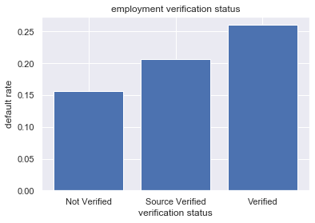

```python
f_default('verification_status')

plt.bar(f_default('verification_status').index, f_default('verification_status').default_rate)
plt.title('employment verification status')
plt.xlabel('verification status')
plt.ylabel('default rate')
plt.show();
```

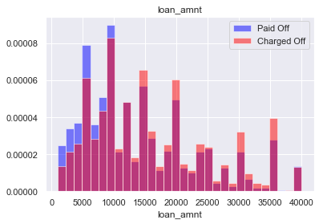

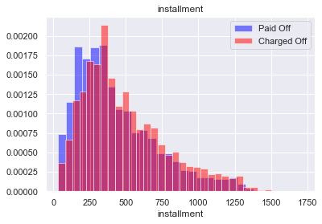

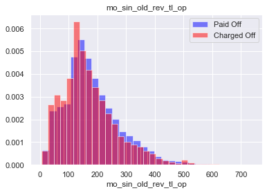

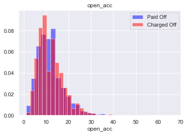

```python
hist_defaults('loan_amnt')
hist_defaults('installment')
hist_defaults('mo_sin_old_rev_tl_op')
hist_defaults('open_acc')
```

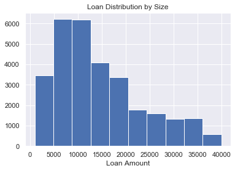

```python
#Basic Histogram
c1s['loan_amnt'].hist()
plt.title('Loan Distribution by Size')
plt.xlabel('Loan Amount')
plt.show();
```

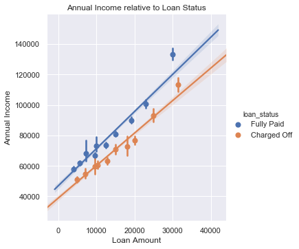

```python
## A graph showing relationship between annual income vs. Paid off v. Charged Off.
sns.lmplot(x = 'loan_amnt', y = 'annual_inc', data = c1s, fit_reg = True, hue = 'loan_status', x_bins = 10)
plt.xlabel('Loan Amount')
plt.ylabel('Annual Income')
plt.title('Annual Income relative to Loan Status')
plt.show();
```

# Target

The graph shows the classes are imbalanced since more loans will be Fully Paid versus Charged Off. Downsampling (Undersampling) was performed to randomly remove samples from the Fully Paid majority class.

Undersampling

Undersampling can be defined as removing some observations of the majority class. Undersampling can be a good choice when you have hundreads of thousands of rows. However this may remove some valuable information that may lead to underfitting and poor generalization to the test set.

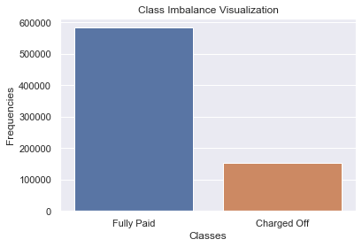

```python
sns.countplot(x="loan_status", data=c1)
plt.xlabel("Classes")
plt.ylabel("Frequencies")
plt.title("Class Imbalance Visualization")
plt.show();
```

# Feature Engineering

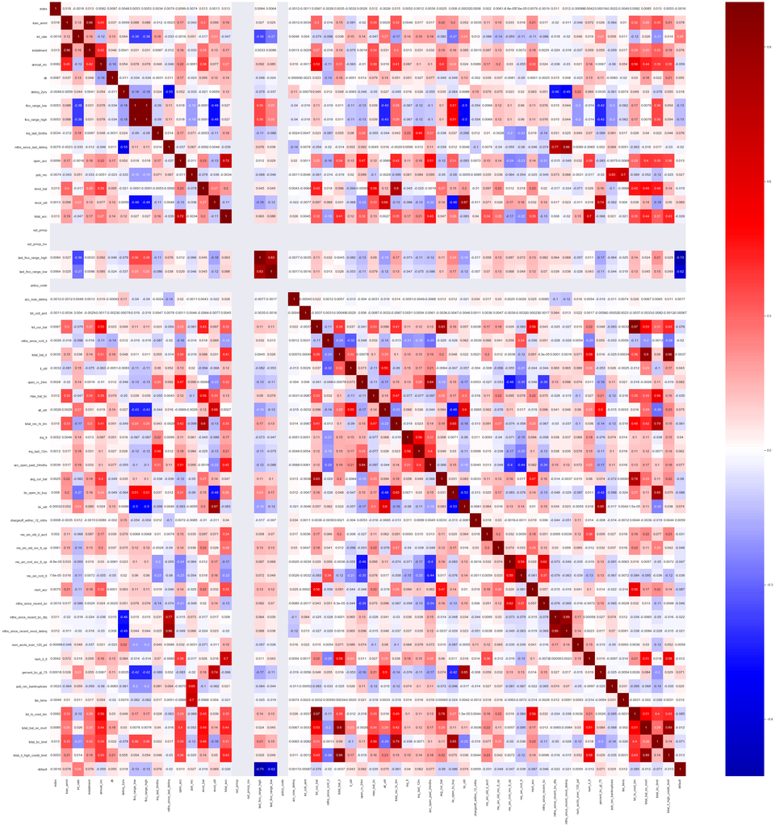

```python
# view correlation of features
plt.figure(figsize=(50,50))
sns.heatmap(c1.corr(),center = 0, cmap = 'seismic',annot = True);
```

# Classificiation Model Selection and Evaluation

The selection is a progression from logistic, decision tree and finally to ensemble classification models.

Train and Test Accuracy scores were measured as well as the test precision and recall.

Optimization of hyperparameters was performed on the selected models.

# Random Forest

The RandomForestClassifier model was the first model. This model is helpful in classification problems where there is a clear class imbalance.

- Train Accuracy scores for the 5 folds: [0.91475688 0.91281387 0.9155519 0.91435404 0.9142544 ]
- Train Mean cross validation score: 0.914
- TrainStandard deviation of cross validatiion score: 0.001
- Test Accuracy score: 0.91
- Test: FBeta score favoring recall: 0.92

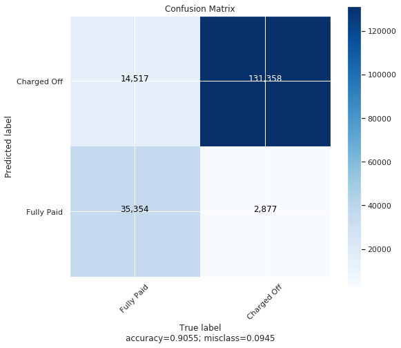

```python
plot_confusion_matrix(cm=confusion, target_names = ['Fully Paid', 'Charged Off'], title = 'Confusion Matrix',normalize=False)
```

# Feature Importance

```python
print(fitop20)
```

```
                          feature  importance
19            last_fico_range_low    0.331786
18           last_fico_range_high    0.251485
55                    fico_change    0.143211
2                        int_rate    0.059878
7                  fico_range_low    0.024535
8                 fico_range_high    0.024480
34                    avg_cur_bal    0.021931
5                             dti    0.014921
3                     installment    0.011288
23                    tot_cur_bal    0.011040
105  verification_status_Verified    0.010705
1                       loan_amnt    0.010279
57                   sub_grade_A3    0.008642
14                     revol_util    0.007710
42                       mort_acc    0.007614
51                tot_hi_cred_lim    0.007428
35                 bc_open_to_buy    0.005831
56                   sub_grade_A2    0.005410
29                       all_util    0.004922
58                   sub_grade_A4    0.003989
```

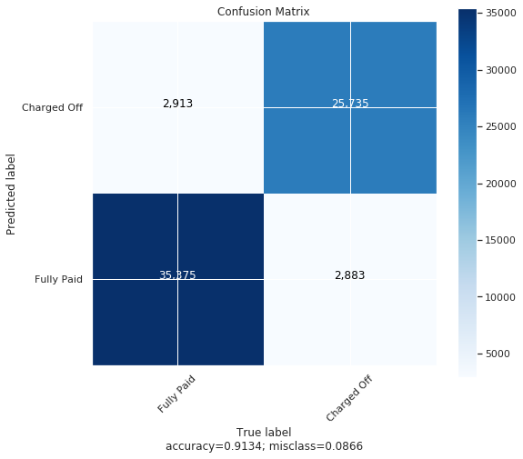

```python
plot_confusion_matrix(cm=confusion, target_names = ['Fully Paid', 'Charged Off'], title = 'Confusion Matrix',normalize=False)
```

## Logistic Regression

The second model was Logistic Regression. The initial parameters for the Logistic Regression were the default values and then I perfomed a GridSearch to find for the ideal C Value parameter.

- Train Accuracy scores for the 5 folds: [0.89649696 0.91869068 0.91908303 0.91949406 0.90867648]
- Train Mean cross validatiion score: 0.912
- Train Standard deviation of cross validatiion score: 0.009
- Test Accuracy score: 0.91
- Test FBeta score favoring recall: 0.88

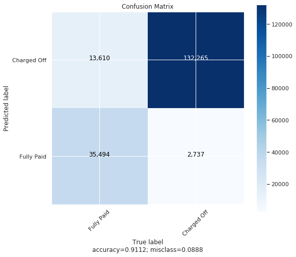

```python
plot_confusion_matrix(cm=confusion, target_names = ['Fully Paid', 'Charged Off'], title = 'Confusion Matrix',normalize=False)
```

# AdaBoost

The third model used was the Adaptive Boosting Classifier, which uses an ensemble of “weak learners” that produce a better predictive model. AdaBoost gives more weight to observations that are difficult to predict.

- Train Accuracy scores for the 5 folds: [0.9028865 0.91983036 0.92020402 0.9184478 0.9064345 ]
- Train Mean cross validatiion score: 0.914
- Train Standard deviation of cross validatiion score: 0.007
- Test FBeta score favoring recall: 0.93

# Gradient Boosting

The fourth model used was the Gradient Boosting. A Gradient Boosted Classification model's goal is too minimize the loss function.

A GridSearch was performed to optimize the hyperparamaters.

- Train Accuracy scores for the 5 folds: [0.90326016 0.92059637 0.92173604 0.92050295 0.90916224]
- Train Mean cross validatiion score: 0.915
- Train Standard deviation of cross validatiion score: 0.007
- Test Accuracy score: 0.92
- Test FBeta score favoring recall: 0.93

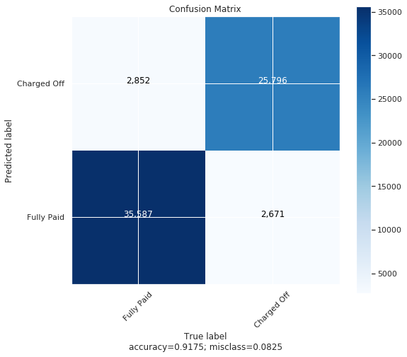

```python
plot_confusion_matrix(cm=confusion, target_names = ['Fully Paid', 'Charged Off'], title = 'Confusion Matrix',normalize=False)
```

# XGBoost

eXtreme Gradient Boosting. The Gradient boosting is an approach where new models are created that predict the residuals or errors of prior models and then added together to make the final prediction. It is called gradient boosting because it uses a gradient descent algorithm to minimize the loss when adding new models.

- Train Accuracy scores for the 5 folds: [0.9056142 0.92104476 0.92132501 0.92012929 0.90895673]
- Train Mean cross validatiion score: 0.915
- Train Standard deviation of cross validatiion score: 0.007
- Test Accuracy score: 0.92
- Test FBeta score favoring recall: 0.93

[figure not shown]

```python
plot_confusion_matrix(cm=confusion, target_names = ['Fully Paid', 'Charged Off'], title = 'Confusion Matrix',normalize=False)
```

# Model Summary Scores

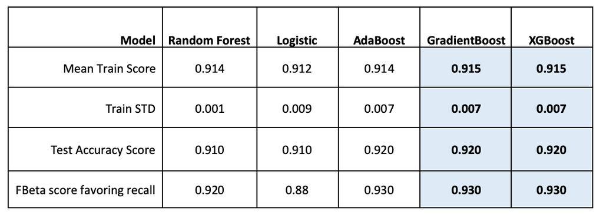

# Summary

Based on the precision and recall scores of the model, we are able to match the current weighted average charge off rate on LendingClub's loans of 8.20%.

This lends credence to the company using a similar proprietary scoring model based on the features used in this project.

Gradient Boosting and eXtreme Gradient Boosting Train CV Score, Test Accuracy Score, and Test Fbeta score favoring recall were identical and either can be used for future development.

[figure not shown]

# Next Steps

Lending Club has done a great job at optimizing their business model through the migration of loans from 60 month to 36 months. This has decreased the default rates, the duration of their investment portfolio to 16 months as well increased the issuance of loans on their marketplace.

Future development will now focus on external factors incorporated into the existing dataset and tailoring the ability to predict charge offs based on more select subsample criteria.

External data such as consumer credit change, demographic data, unemployment data, word analysis of the Federal Reserve forward guidance, and retails sales for a better view on lending as that is the key driver to the business.